# BTS_EDA

Rachel Regberg

11/9/2019

## Read in Data

```r
#These libraries are required for reading, parsing, and tidying the data
library(tidyverse)
library(lubridate)

#This function takes in a .csv file with the data format laid out from the previous section, containing the minimum set of variables. The file is converted to an R data frame with the variable names transformed for readability. Some column types that are produced by the read_csv parser based on heuristics do not contain the desired type, so these are "force"" parsed to that desired type.
data_reader <- function(data_file){
  output_file <- read_csv(data_file,
                  skip = 1,
                  col_names = c("Date", "Carrier_Code", "Origin", "Origin_City", "Dest", "Dest_City",
                                "Dep_Time_Planned", "Dep_Time_Actual", "Wheels_Off", "Wheels_On",
                                "Arr_Time_Planned", "Arr_Time_Actual", "Cancelled", "Cancellation_Code",
                                "Diverted", "Air_Time", "Distance", "Empty"),
                  col_types = cols(
                    Cancelled = col_factor(),
                    Cancellation_Code = col_factor(),
                    Diverted = col_factor())
                  )
  return(output_file)
}

#This function takes an R data frame as input and performs tidy operations on it. The variables containing times are parsed to the correct time formate using lubridate. The Origin and Destination cities are separated into city name and state columns. The computed subset of variables specified in the previous section are generated here. Some factor variables are re-coded based on the lookup tables from BTS
data_tidy <- function(input_frame){
  input_frame %>%
    mutate(Date = ymd(Date),
           Dep_Time_Planned = hm(str_replace(Dep_Time_Planned, "(\\d\\d)(\\d\\d)", "\\1 \\2"), quiet = TRUE),
           Dep_Time_Actual = hm(str_replace(Dep_Time_Actual, "(\\d\\d)(\\d\\d)", "\\1 \\2"), quiet = TRUE),
           Arr_Time_Planned = hm(str_replace(Arr_Time_Planned, "(\\d\\d)(\\d\\d)", "\\1 \\2"), quiet = TRUE),
           Arr_Time_Actual = hm(str_replace(Arr_Time_Actual, "(\\d\\d)(\\d\\d)", "\\1 \\2"), quiet = TRUE),
           Wheels_Off = hm(str_replace(Wheels_Off, "(\\d\\d)(\\d\\d)", "\\1 \\2"), quiet = TRUE),
           Wheels_On = hm(str_replace(Wheels_On, "(\\d\\d)(\\d\\d)", "\\1 \\2"), quiet = TRUE),
           Air_Time = dminutes(Air_Time),
           Dep_Delay = Dep_Time_Actual - Dep_Time_Planned,
           Arr_Delay = Arr_Time_Actual - Arr_Time_Planned,
           Taxi_Out = Wheels_Off - Dep_Time_Actual,
           Taxi_In = Arr_Time_Actual - Wheels_On,
           Cancelled = fct_recode(Cancelled, "Yes" = "1.00", "No" = "0.00"),
           Diverted = fct_recode(Diverted, "Yes" = "1.00", "No" = "0.00"),
           Cancellation_Code = fct_recode(Cancellation_Code,
                                          "Carrier" = "A",
                                          "Weather" = "B",
                                          "National Air System" = "C",
                                          "Security" = "D")) %>%
    separate(Origin_City, into = c("Origin_City", "Origin_State"), sep = ", ") %>%
    separate(Dest_City, into = c("Dest_City", "Dest_State"), sep = ", ")-> output_frame
  return(output_frame)
}

#Placeholder for other tidy functions:
#Todo: (1) Create tidy function to check for erroneous data using heuristics. For example, there are some flights that have a departure time and wheels off time when the flight is cancelled. (2) A function may be required to merge in the airline lookup table, since the airlines are observed by code in the data set

#Read in the unique carrier code lookup from BTS
lookup_carrier <- read_csv("../data/lookup_carrier.csv",
                           col_names = c("Code", "Carrier_Name"))
#Create a list of the files in the "data" driectory, containing the file names
data_files <- list.files(path = "../data")

#Create a list of the flight data files
flight_data_index <-str_detect(data_files, "flight_data")
flight_data_files <- data_files[flight_data_index]

#Create the data list that will used for analysis. The list elements will containg data frames for each calendar month
data_list <- vector(mode = "list")

#Create a data frame for flights in 2018, to be populated with random samples from each month of 2018
flights_2018 <- c()

#Populate the data list with data frames generated from the files in the "data" directory. Each file is read in using the "data_reader" function and tidy operations are performed by the "data_tidy" function. Each generated data frame is then inserted into the "data_list" with the element name generated from the "month_year" portion of the file name. The file name format must contain "..._month_year.csv", with "month" being a 3 letter abbreviation for each month.
for (i in seq_along(flight_data_files)){
  data_list_index <- str_extract(flight_data_files[i], '....(\\d+)')
  filename <- str_c("../data/", flight_data_files[i])
  flight_file_input <- data_reader(filename)
  merge_carrier <- left_join(flight_file_input, lookup_carrier, by = c("Carrier_Code" = "Code"))
  data_list[[data_list_index]] <- data_tidy(merge_carrier)
  flights_2018 <- rbind(flights_2018, sample_n(data_list[[data_list_index]], 1000))
}
```

Remove unnecessary items from the Environment.

```r
rm(data_list, lookup_carrier, merge_carrier, data_files, flight_data_files, flight_data_index, flight_file_input, data_list_index, filename, data_reader, data_tidy)
```

Correct `Dep_Delay`, `Arr_Delay`, `Taxi_Out`, and `Taxi_In` variables to show correct duration.

```r
flights_2018$Dep_Delay <- as.integer(as.duration(flights_2018$Dep_Time_Actual) -
                                       as.duration(flights_2018$Dep_Time_Planned))/60
flights_2018$Arr_Delay <- as.integer(as.duration(flights_2018$Arr_Time_Actual) -
                                       as.duration(flights_2018$Arr_Time_Planned))/60
flights_2018$Taxi_Out <- as.integer(as.duration(flights_2018$Wheels_Off) -
                                      as.duration(flights_2018$Dep_Time_Actual))/60
flights_2018$Taxi_In <- as.integer(as.duration(flights_2018$Arr_Time_Actual) -
                                     as.duration(flights_2018$Wheels_On))/60
```

```r
#adds month, day of month, and weekday for each observation
flights_2018 <- flights_2018 %>%
  mutate(Month = month(Date)) %>%
  mutate(Day = mday(Date)) %>%
  mutate(Weekday = wday(Date, label = TRUE))
#converts planned departure time to integer time for analysis by time of day
hour <- as.character(hour(flights_2018$Dep_Time_Planned))
minute <- as.character(minute(flights_2018$Dep_Time_Planned))
for (i in seq_along(hour)) {
  ifelse(hour[i] %in% as.character(seq(1,9,1)), hour[i] <- str_c("0",hour[i]), hour[i])
}
for (i in seq_along(minute)) {
  ifelse(minute[i] %in% as.character(seq(0,9,1)), minute[i] <- str_c("0",minute[i]), minute[i])
}
hour_minute <- as.integer(str_c(hour, minute))
flights_2018$Dep_Time_Planned_Time <- hour_minute
rm(hour, hour_minute, minute)
#converts planned arrival time to integer time for analysis by time of day
hour <- as.character(hour(flights_2018$Arr_Time_Planned))
minute <- as.character(minute(flights_2018$Arr_Time_Planned))
for (i in seq_along(hour)) {
  ifelse(hour[i] %in% as.character(seq(1,9,1)), hour[i] <- str_c("0",hour[i]), hour[i])
}
for (i in seq_along(minute)) {
  ifelse(minute[i] %in% as.character(seq(0,9,1)), minute[i] <- str_c("0",minute[i]), minute[i])
}
hour_minute <- as.integer(str_c(hour, minute))
flights_2018$Arr_Time_Planned_Time <- hour_minute
rm(hour, hour_minute, minute)
```

```r
flights_2018 %>%
  mutate(Carrier_Code=as.factor(Carrier_Code),
         Origin=as.factor(Origin),
         Origin_City=as.factor(Origin_City),
         Origin_State=as.factor(Origin_State),
         Dest=as.factor(Dest),
         Dest_City=as.factor(Dest_City),
         Dest_State=as.factor(Dest_State),
         Cancelled=as.factor(Cancelled),
         Cancellation_Code=as.factor(Cancellation_Code),
         Diverted=as.factor(Diverted),
         Carrier_Name=as.factor(Carrier_Name),
         Air_Time=as.double(Air_Time)) -> flights_2018

glimpse(flights_2018)
```

```
## Observations: 12,000
## Variables: 30
## $ Date                  <date> 2018-04-28, 2018-04-12, 2018-04-26, 201...
## $ Carrier_Code          <fct> YV, WN, DL, OO, WN, OO, B6, EV, DL, OO, ...
## $ Origin                <fct> DFW, LAS, SFO, IAH, SNA, CLE, LAX, LGA, ...
## $ Origin_City           <fct> Dallas/Fort Worth, Las Vegas, San Franci...
## $ Origin_State          <fct> TX, NV, CA, TX, CA, OH, CA, NY, GA, MN, ...
## $ Dest                  <fct> BIS, SAT, DTW, MOB, SJC, ORD, JFK, XNA, ...
## $ Dest_City             <fct> Bismarck/Mandan, San Antonio, Detroit, M...
## $ Dest_State            <fct> ND, TX, MI, AL, CA, IL, NY, AR, TN, SD, ...
## $ Dep_Time_Planned      <Period> 13H 0M 0S, 5H 25M 0S, 22H 25M 0S, 16H...
## $ Dep_Time_Actual       <Period> 12H 52M 0S, 5H 33M 0S, 22H 18M 0S, 16...
## $ Wheels_Off            <Period> 13H 0M 0S, 5H 41M 0S, 22H 31M 0S, 16H...
## $ Wheels_On             <Period> 15H 12M 0S, 9H 49M 0S, 5H 34M 0S, 17H...
## $ Arr_Time_Planned      <Period> 15H 41M 0S, 9H 55M 0S, 6H 1M 0S, 17H ...
```

[output cut: 17 more lines]

```r
summary(flights_2018[c(2:8, 15:19, 21:22)])
```

```
##   Carrier_Code      Origin                Origin_City    Origin_State
##  WN     :2287   ATL    : 636   Chicago          : 686   CA     :1306
##  DL     :1532   ORD    : 516   Atlanta          : 636   TX     :1268
##  AA     :1517   DFW    : 451   New York         : 489   FL     : 929
##  OO     :1296   CLT    : 435   Dallas/Fort Worth: 451   IL     : 717
##  UA     :1014   DEN    : 390   Charlotte        : 435   GA     : 672
##  YX     : 552   LAX    : 347   Houston          : 398   NY     : 624
##  (Other):3802   (Other):9225   (Other)          :8905   (Other):6484
##       Dest                  Dest_City      Dest_State   Cancelled
##  ATL    : 645   Chicago          : 739   CA     :1363   No :11808
##  ORD    : 601   Atlanta          : 645   TX     :1243   Yes:  192
##  DFW    : 471   New York         : 498   FL     : 912
##  CLT    : 394   Dallas/Fort Worth: 471   IL     : 760
##  DEN    : 390   Charlotte        : 394   GA     : 692
##  LAX    : 365   Denver           : 390   NY     : 632
##  (Other):9134   (Other)          :8863   (Other):6398
##            Cancellation_Code Diverted       Air_Time        Distance
##  Carrier            :   49   No :11964   Min.   :  600   Min.   :  31
##  Security           :    0   Yes:   36   1st Qu.: 3540   1st Qu.: 358
##  Weather            :  101               Median : 5520   Median : 626
##  National Air System:   42               Mean   : 6668   Mean   : 795
##  NA's               :11808               3rd Qu.: 8400   3rd Qu.:1025
##                                          Max.   :38460   Max.   :4983
##                                          NA's   :228
##                  Carrier_Name    Dep_Delay
##  Southwest Airlines Co.:2287   Min.   :-1422.000
##  Delta Air Lines Inc.  :1532   1st Qu.:   -6.000
##  American Airlines Inc.:1517   Median :   -2.000
##  SkyWest Airlines Inc. :1296   Mean   :    4.005
##  United Air Lines Inc. :1014   3rd Qu.:    6.000
##  Republic Airline      : 552   Max.   :  836.000
##  (Other)               :3802   NA's   :188
```

Total NA’s in select variables:

```r
#returns NAs for factor-related variables to verify they match the number of cancelled flights.
flights_2018[c(15:17, 21:22)] %>%
  summarize_all(funs(sum(is.na(.))))
```

```
## # A tibble: 1 x 5
##   Cancelled Cancellation_Code Diverted Carrier_Name Dep_Delay
##       <int>             <int>    <int>        <int>     <int>
## 1         0             11808        0            0       188
```

As noticed above, `Cancellation_Code` and `Dep_Delay` have significant NAs.

```r
flights_cancel <- flights_2018 %>%
  filter(Cancelled == "Yes")
flights_divert <- flights_2018 %>%
  filter(Diverted == "Yes")
```

```r
mean_arr_delay <- aggregate(Arr_Delay~Carrier_Code + Month, data=flights_2018, mean)
mean_arr_delay %>%
  arrange(desc(Arr_Delay))
```

```
##     Carrier_Code Month    Arr_Delay
## 1             G4     5   74.7142857
## 2             NK     3   57.2068966
## 3             UA     2   54.7297297
## 4             NK     8   49.1200000
## 5             MQ     5   46.6808511
## 6             AS     3   40.1034483
## 7             AS     4   35.9750000
## 8             AS     9   28.3658537
## 9             B6     2   27.4745763
## 10            OH     5   26.1944444
## 11            UA     3   24.7272727
## 12            B6     5   23.9687500
## 13            F9     2   23.0714286
## 14            G4     7   23.0666667
```

[output cut: 193 more lines]

```r
mean_dep_delay <- aggregate(Dep_Delay~Carrier_Code + Month, data=flights_2018, mean)
mean_dep_delay %>%
  arrange(desc(Dep_Delay))
```

```
##     Carrier_Code Month    Dep_Delay
## 1             G4     5   76.1428571
## 2             F9     7   72.8888889
## 3             EV    10   38.6521739
## 4             B6     8   35.8857143
## 5             OH     6   34.2500000
## 6             F9     2   30.5000000
## 7             EV     1   27.2380952
## 8             F9     6   26.2222222
## 9             G4     7   25.2666667
## 10            YV     9   24.1600000
## 11            OO    11   23.4660194
## 12            OH     5   22.3333333
## 13            F9    12   21.8000000
## 14            G4     6   21.2000000
```

[output cut: 193 more lines]

```r
Delays <- aggregate(cbind(Arr_Delay, Dep_Delay) ~ Carrier_Code, flights_2018, mean)
Delays
```

```
##    Carrier_Code   Arr_Delay  Dep_Delay
## 1            9E  -6.6048387  8.8279570
## 2            AA -14.0415828  5.4292421
## 3            AS   4.8249400 -5.3573141
## 4            B6 -15.1323829 -8.7413442
## 5            DL -14.1041940  0.7529489
## 6            EV -10.8623853  6.1712538
## 7            F9 -39.3825137  5.0273224
## 8            G4   4.3134328  5.8880597
## 9            HA  -9.7054264  0.8992248
## 10           MQ   2.4302554  5.6660118
## 11           NK -35.3675497 -8.0099338
## 12           OH -25.0492505 -0.4089936
## 13           OO  -4.9437500  8.6703125
## 14           UA  -1.7171315  7.1792829
## 15           VX  -8.7619048 -1.4761905
## 16           WN -10.9078772  6.1673342
## 17           YV -10.9579832  6.5910364
## 18           YX   0.5859519  6.3641405
```

```r
flights_2018 %>%
  group_by(Carrier_Code, Carrier_Name) %>%
  summarise(Mean_Distance = mean(Distance, na.rm=TRUE),
            Mean_Arr_Delay = mean(Arr_Delay, na.rm=TRUE),
            Mean_Dep_Delay = mean(Dep_Delay, na.rm=TRUE),
            Num_Flights = n())
```

```
## # A tibble: 18 x 6
## # Groups:   Carrier_Code [18]
##    Carrier_Code Carrier_Name Mean_Distance Mean_Arr_Delay Mean_Dep_Delay
##    <fct>        <fct>                <dbl>          <dbl>          <dbl>
##  1 9E           Endeavor Ai~          470.         -6.60           8.83
##  2 AA           American Ai~         1011.        -14.0            5.46
##  3 AS           Alaska Airl~         1275.          4.82          -5.36
##  4 B6           JetBlue Air~         1085.        -15.1           -8.74
##  5 DL           Delta Air L~          853.        -14.1            0.753
##  6 EV           ExpressJet ~          469.        -10.9            6.17
##  7 F9           Frontier Ai~          998.        -39.4            5.03
##  8 G4           Allegiant A~          879.          4.31           5.81
##  9 HA           Hawaiian Ai~          920.         -9.71           0.899
## 10 MQ           Envoy Air             429.          2.43           5.65
## 11 NK           Spirit Air ~         1039.        -35.4           -8.01
## 12 OH           PSA Airline~          383.        -25.0           -0.409
## 13 OO           SkyWest Air~          476.         -4.94           8.79
## 14 UA           United Air ~         1205.         -1.72           7.18
## 15 VX           Virgin Amer~         1383.         -8.76          -1.48
## 16 WN           Southwest A~          754.        -10.9            5.72
## 17 YV           Mesa Airlin~          571.        -11.0            6.59
## 18 YX           Republic Ai~          583.          0.586          6.36
## # ... with 1 more variable: Num_Flights <int>
```

```r
flights_2018 %>%
  group_by(Carrier_Code, Carrier_Name) %>%
  summarise(Max_Distance = max(Distance, na.rm=TRUE),
            Max_Arr_Delay = max(Arr_Delay, na.rm=TRUE),
            Max_Dep_Delay = max(Dep_Delay, na.rm=TRUE),
            Num_Flights = n())
```

```
## # A tibble: 18 x 6
## # Groups:   Carrier_Code [18]
##    Carrier_Code Carrier_Name Max_Distance Max_Arr_Delay Max_Dep_Delay
##    <fct>        <fct>               <dbl>         <dbl>         <dbl>
##  1 9E           Endeavor Ai~         1391           306           312
##  2 AA           American Ai~         3784          1426           478
##  3 AS           Alaska Airl~         2874          1437           158
##  4 B6           JetBlue Air~         2704          1422           316
##  5 DL           Delta Air L~         2994          1424           743
##  6 EV           ExpressJet ~         1147           377           836
##  7 F9           Frontier Ai~         2154           254           276
##  8 G4           Allegiant A~         1678           563           572
##  9 HA           Hawaiian Ai~         4983            73           149
## 10 MQ           Envoy Air            1437          1430           373
## 11 NK           Spirit Air ~         2402          1423           823
## 12 OH           PSA Airline~         1095           727           710
## 13 OO           SkyWest Air~         1694           740           741
## 14 UA           United Air ~         4817          1432           768
## 15 VX           Virgin Amer~         2704            51            50
## 16 WN           Southwest A~         2555          1435           544
## 17 YV           Mesa Airlin~         1530           352           268
## 18 YX           Republic Ai~         1504          1411           330
## # ... with 1 more variable: Num_Flights <int>
```

Top 10 Airlines

```r
flights_2018 %>%
  group_by(Carrier_Name) %>%
  summarise(Num_Carrier = n()) %>%
  arrange(desc(Num_Carrier)) %>%
  top_n(10)
```

```
## # A tibble: 10 x 2
##    Carrier_Name           Num_Carrier
##    <fct>                        <int>
##  1 Southwest Airlines Co.        2287
##  2 Delta Air Lines Inc.          1532
##  3 American Airlines Inc.        1517
##  4 SkyWest Airlines Inc.         1296
##  5 United Air Lines Inc.         1014
##  6 Republic Airline               552
##  7 Envoy Air                      530
##  8 JetBlue Airways                500
##  9 PSA Airlines Inc.              480
## 10 Alaska Airlines Inc.           425
```

Top 10 Origin Cities

```r
flights_2018 %>%
  group_by(Origin_City) %>%
  summarise(Num_O_City = n()) %>%
  arrange(desc(Num_O_City)) %>%
  top_n(10)
```

```
## # A tibble: 10 x 2
##    Origin_City       Num_O_City
##    <fct>                  <int>
##  1 Chicago                  686
##  2 Atlanta                  636
##  3 New York                 489
##  4 Dallas/Fort Worth        451
##  5 Charlotte                435
##  6 Houston                  398
##  7 Denver                   390
##  8 Los Angeles              347
##  9 Washington               325
## 10 Phoenix                  323
```

Top 10 Origin States

```r
flights_2018 %>%
  group_by(Origin_State) %>%
  summarise(Num_O_State = n()) %>%
  arrange(desc(Num_O_State)) %>%
  top_n(10)
```

```
## # A tibble: 10 x 2
##    Origin_State Num_O_State
##    <fct>              <int>
##  1 CA                  1306
##  2 TX                  1268
##  3 FL                   929
##  4 IL                   717
##  5 GA                   672
##  6 NY                   624
##  7 NC                   601
##  8 CO                   434
##  9 AZ                   361
## 10 MI                   341
```

Top 10 Destination Cities

```r
flights_2018 %>%
  group_by(Dest_City) %>%
  summarise(Num_D_Cities = n()) %>%
  arrange(desc(Num_D_Cities)) %>%
  top_n(10)
```

```
## # A tibble: 10 x 2
##    Dest_City         Num_D_Cities
##    <fct>                    <int>
##  1 Chicago                    739
##  2 Atlanta                    645
##  3 New York                   498
##  4 Dallas/Fort Worth          471
##  5 Charlotte                  394
##  6 Denver                     390
##  7 Houston                    367
##  8 Los Angeles                365
##  9 Phoenix                    343
## 10 Washington                 318
```

Top 10 Destination States

```r
flights_2018 %>%
  group_by(Dest_State) %>%
  summarise(Num_D_State = n()) %>%
  arrange(desc(Num_D_State)) %>%
  top_n(10)
```

```
## # A tibble: 10 x 2
##    Dest_State Num_D_State
##    <fct>            <int>
##  1 CA                1363
##  2 TX                1243
##  3 FL                 912
##  4 IL                 760
##  5 GA                 692
##  6 NY                 632
##  7 NC                 556
##  8 CO                 442
##  9 AZ                 384
## 10 MI                 351
```

Top 10 Carriers

```r
flights_2018 %>%
  group_by(Carrier_Code) %>%
  summarise(Num_Carrier = n()) %>%
  arrange(desc(Num_Carrier)) %>%
  top_n(10)
```

```
## # A tibble: 10 x 2
##    Carrier_Code Num_Carrier
##    <fct>              <int>
##  1 WN                  2287
##  2 DL                  1532
##  3 AA                  1517
##  4 OO                  1296
##  5 UA                  1014
##  6 YX                   552
##  7 MQ                   530
##  8 B6                   500
##  9 OH                   480
## 10 AS                   425
```

## Plots - Response Variables

Departure Delay

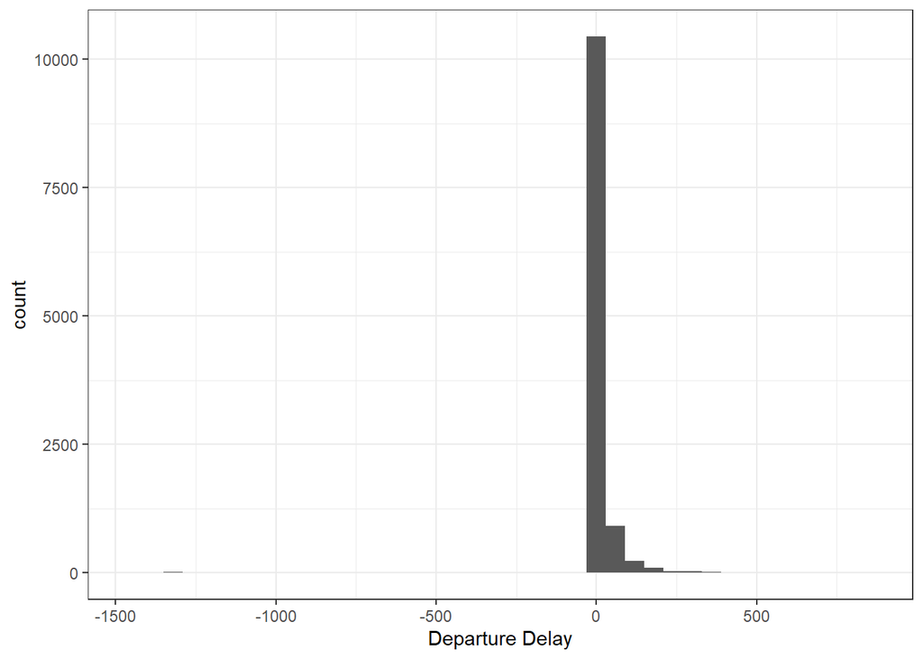

```r
ggplot(flights_2018, aes(x = Dep_Delay)) +
  geom_histogram(binwidth = 60) +
  theme_bw() +
  xlab("Departure Delay")
```

We can see it is skewed to the right which indicates more departure delays.

Arrival Delay

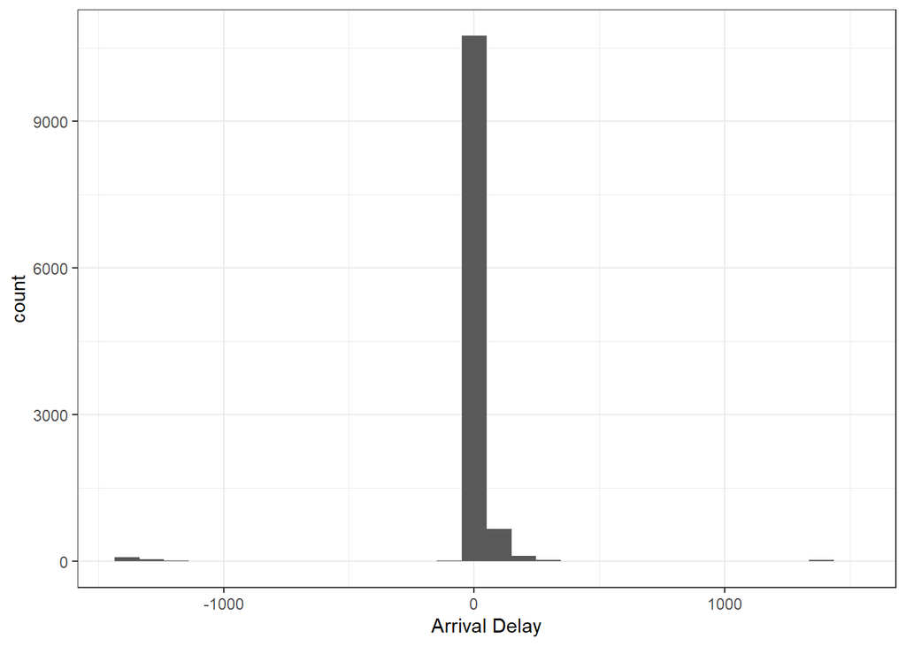

```r
ggplot(flights_2018, aes(x = Arr_Delay)) +
  geom_histogram(bindwidth = 60) +
  theme_bw() +
  xlab("Arrival Delay")
```

We can see it is skewed to the right which indicates more arrival delays.

Cancelled

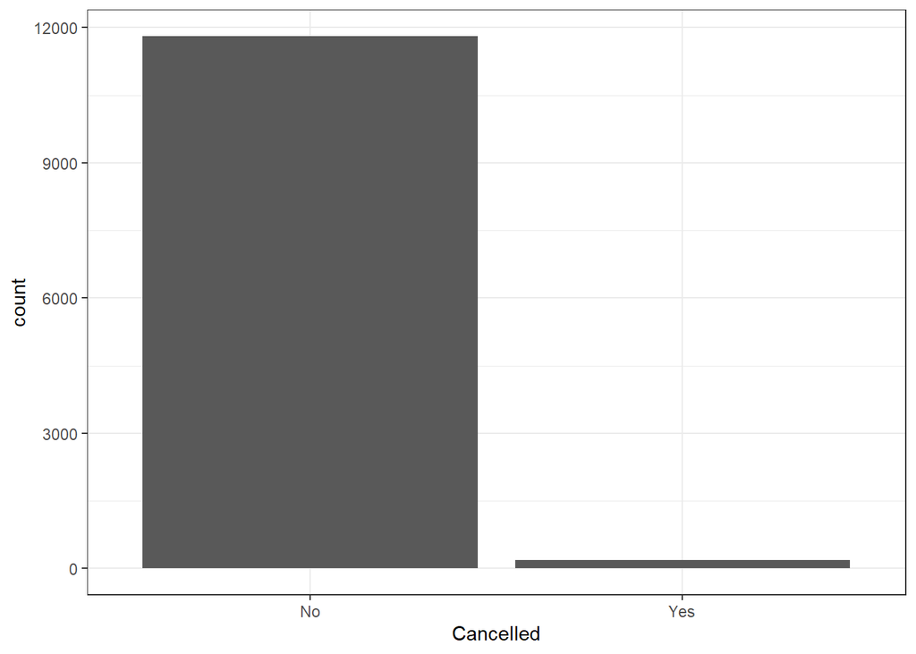

```r
ggplot(flights_2018, aes(x = Cancelled)) +
  geom_bar() +
  theme_bw() +
  xlab("Cancelled")
```

Cancellation Code

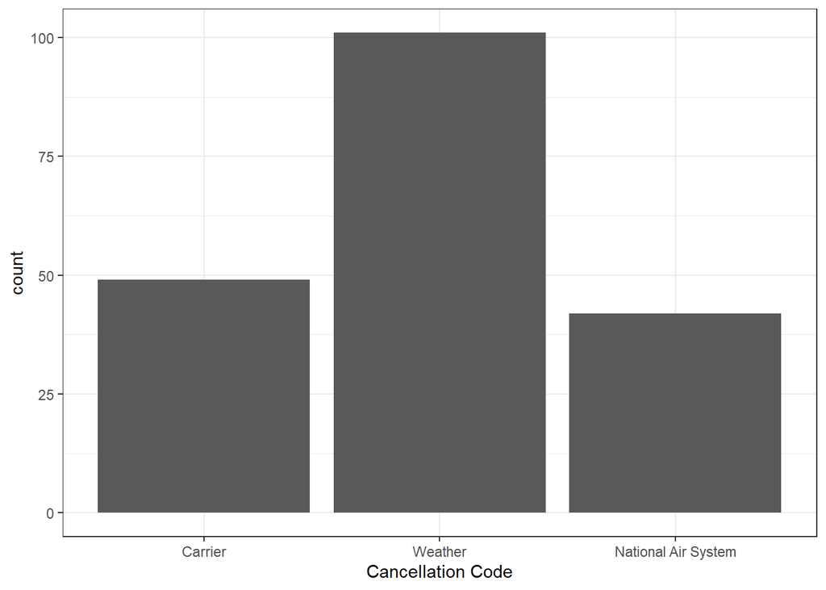

```r
flights_2018 %>%
  filter(!is.na(Cancellation_Code)) %>%
  ggplot(aes(x = Cancellation_Code)) +
  geom_bar() +
  theme_bw() +
  xlab("Cancellation Code")
```

Weather is the biggest factor for cancelled flights.

Diverted

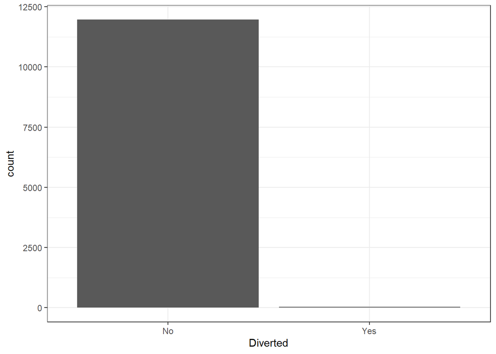

```r
ggplot(flights_2018, aes(x = Diverted)) +
  geom_bar() +
  theme_bw() +
  xlab("Diverted")
```

Very few flights are diverted.

Carriers

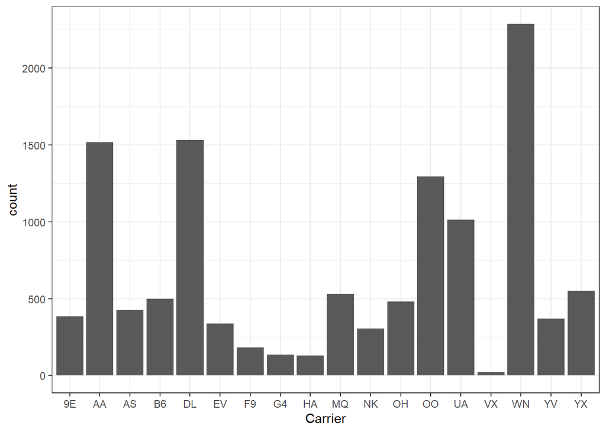

```r
ggplot(flights_2018, aes(x = Carrier_Code)) +
  geom_bar() +
  theme_bw() +
  xlab("Carrier")
```

WN is the top carrier code in this year.

Carrier Name

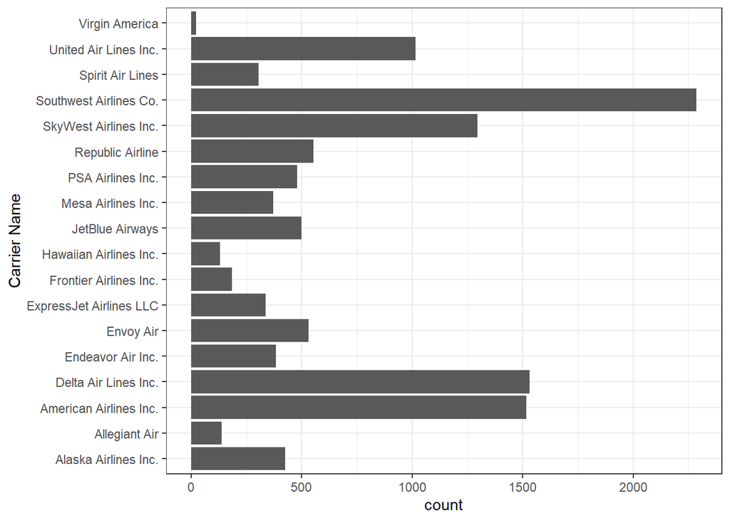

```r
ggplot(flights_2018, aes(x = Carrier_Name)) +
  geom_bar() +
  theme_bw() +
  xlab("Carrier Name") +
  coord_flip()
```

Southwest Airlines Co is the top carrier in this year.

## Plots - Explanatory Variables

Air Time

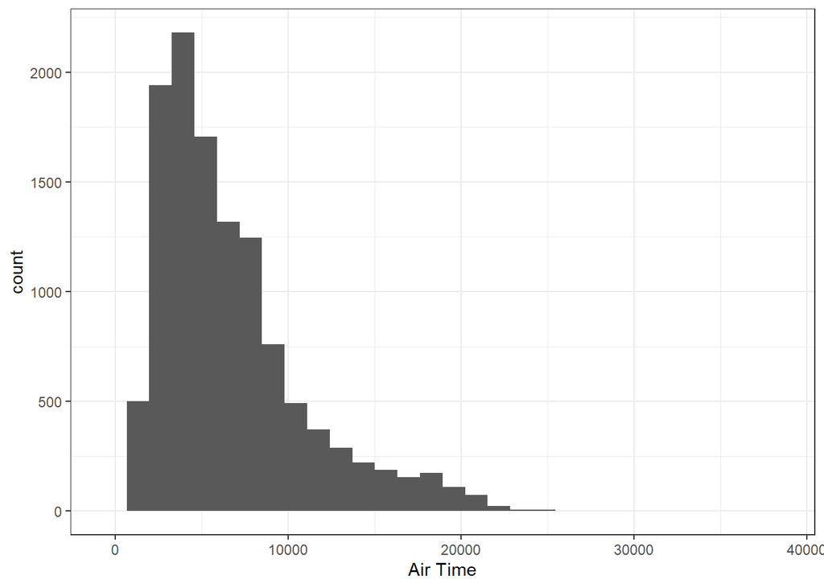

```r
ggplot(flights_2018, aes(x = Air_Time)) +
  geom_histogram() +
  theme_bw() +
  xlab("Air Time")
```

```r
flights_2018 %>%
  summarise(mean_air = mean(Air_Time))
```

```
## # A tibble: 1 x 1
##   mean_air
##      <dbl>
## 1       NA
```

```r
class(flights_2018$Air_Time)
```

```
## [1] "numeric"
```

Distance

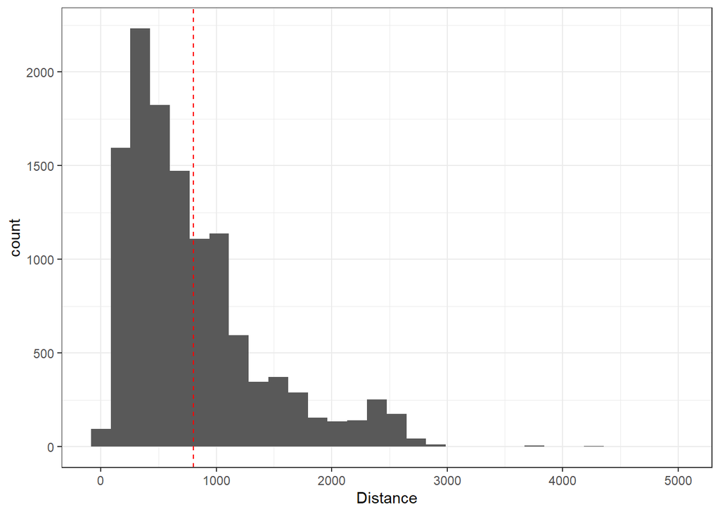

```r
ggplot(flights_2018, aes(x = Distance)) +
  geom_histogram() +
  geom_vline(xintercept = 802, lty = 2, color = "red") +

  theme_bw() +
  xlab("Distance")
```

```r
flights_2018 %>%
  summarise(mean = mean(Distance))
```

```
## # A tibble: 1 x 1
##    mean
##   <dbl>
## 1  795.
```

Skewed to longer distance flights.

Origin (top 20)

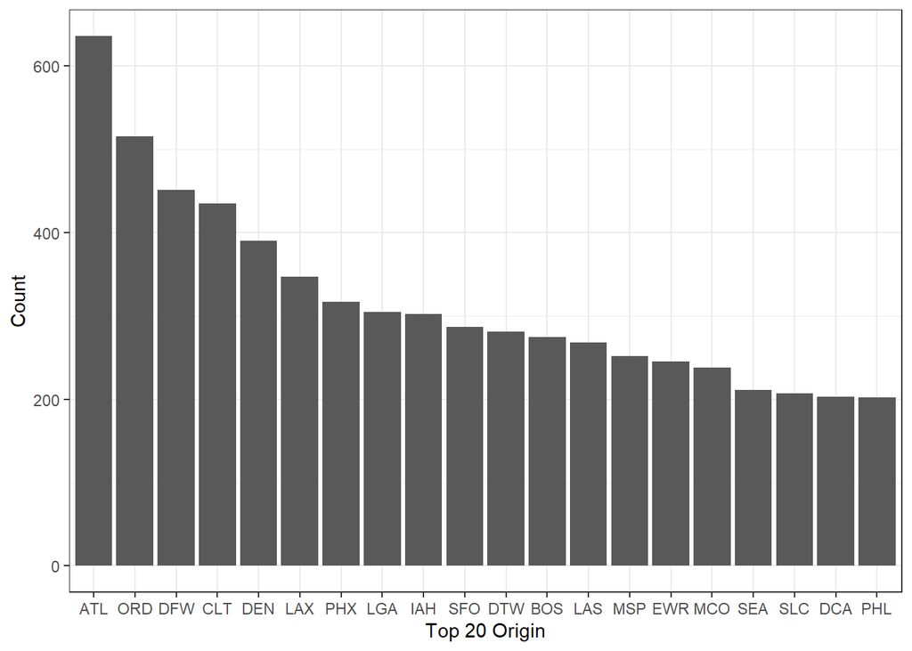

```r
flights_2018 %>%
  group_by(Origin) %>%
  summarise(Num_Origin = n()) %>%
  arrange(desc(Num_Origin)) %>%
  top_n(20) %>%
  ggplot(aes(x=reorder(Origin, -Num_Origin), y = Num_Origin)) +
  geom_bar(stat = "identity") +
  theme_bw() +
  xlab("Top 20 Origin") +
  ylab("Count")
```

Origin Cities (Top 20)

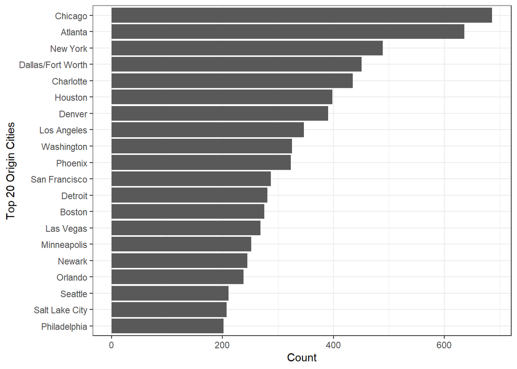

```r
flights_2018 %>%
  group_by(Origin_City) %>%
  summarise(Num_Origin = n()) %>%
  arrange(desc(Num_Origin)) %>%
  top_n(20) %>%
  ggplot(aes(x=reorder(Origin_City, Num_Origin), y = Num_Origin)) +
  geom_bar(stat = "identity") +
  theme_bw() +
  xlab("Top 20 Origin Cities") +
  ylab("Count") +
  coord_flip()
```

Origin States (Top 20)

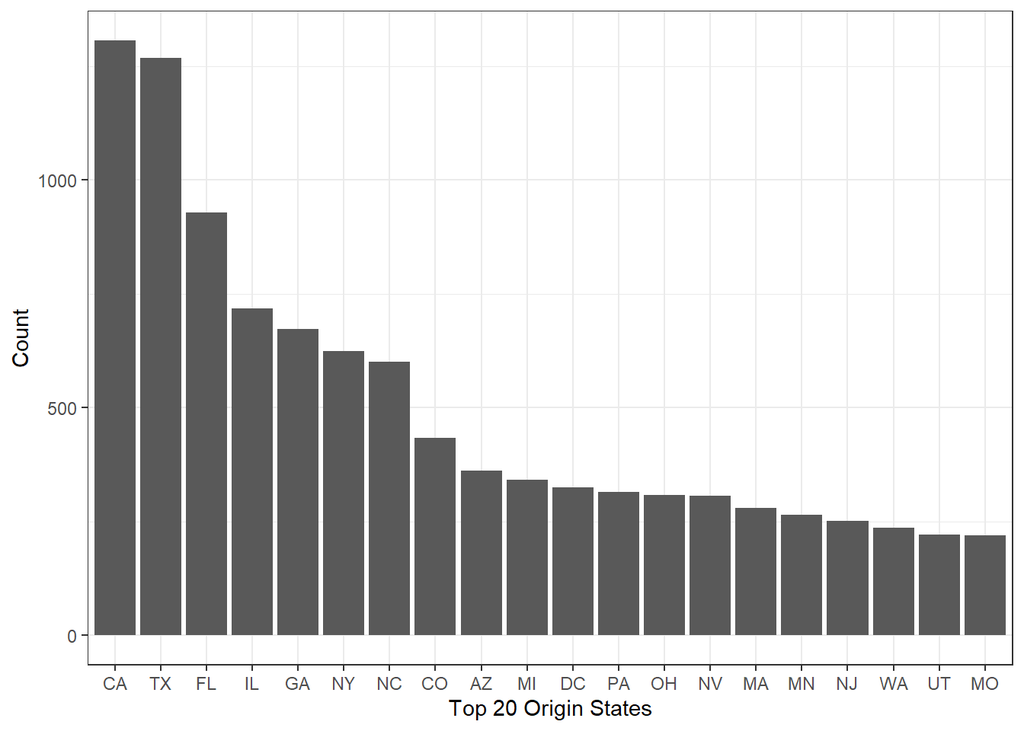

```r
flights_2018 %>%
  group_by(Origin_State) %>%
  summarise(Num_Origin = n()) %>%
  arrange(desc(Num_Origin)) %>%
  top_n(20) %>%
  ggplot(aes(x=reorder(Origin_State, -Num_Origin), y = Num_Origin)) +
  geom_bar(stat = "identity") +
  theme_bw() +
  xlab("Top 20 Origin States") +
  ylab("Count")
```

Destination (Top 20)

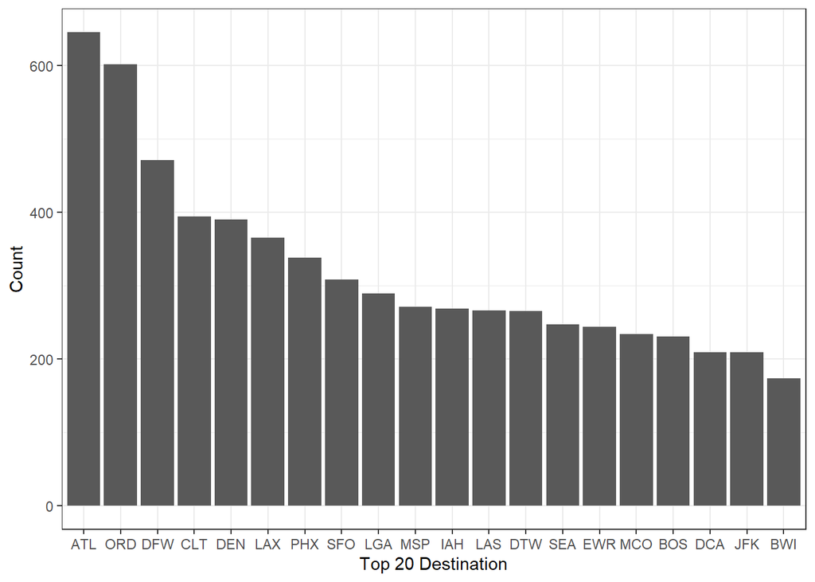

```r
flights_2018 %>%
  group_by(Dest) %>%
  summarise(Num_Dest = n()) %>%
  arrange(desc(Num_Dest)) %>%
  top_n(20) %>%
  ggplot(aes(x=reorder(Dest, -Num_Dest), y = Num_Dest)) +
  geom_bar(stat = "identity") +
  theme_bw() +
  xlab("Top 20 Destination") +
  ylab("Count")
```

Destination Cities (Top 20)

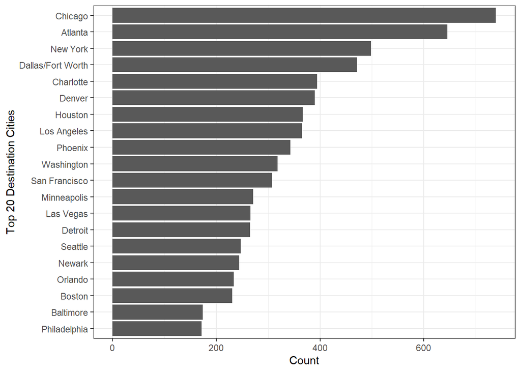

```r
flights_2018 %>%
  group_by(Dest_City) %>%
  summarise(Num_Dest = n()) %>%
  arrange(desc(Num_Dest)) %>%
  top_n(20) %>%
  ggplot(aes(x=reorder(Dest_City, Num_Dest), y = Num_Dest)) +
  geom_bar(stat = "identity") +
  theme_bw() +
  xlab("Top 20 Destination Cities") +
  ylab("Count") +
  coord_flip()
```

Destination States (Top 20)

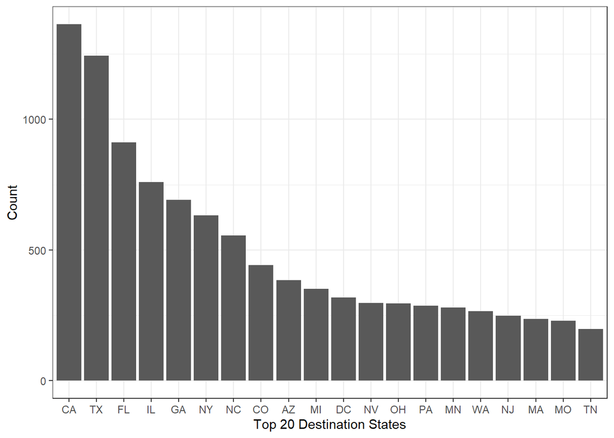

```r
flights_2018 %>%
  group_by(Dest_State) %>%
  summarise(Num_Dest = n()) %>%
  arrange(desc(Num_Dest)) %>%
  top_n(20) %>%
  ggplot(aes(x=reorder(Dest_State, -Num_Dest), y = Num_Dest)) +
  geom_bar(stat = "identity") +
  theme_bw() +
  xlab("Top 20 Destination States") +
  ylab("Count")
```

Groouped by Taxi_In

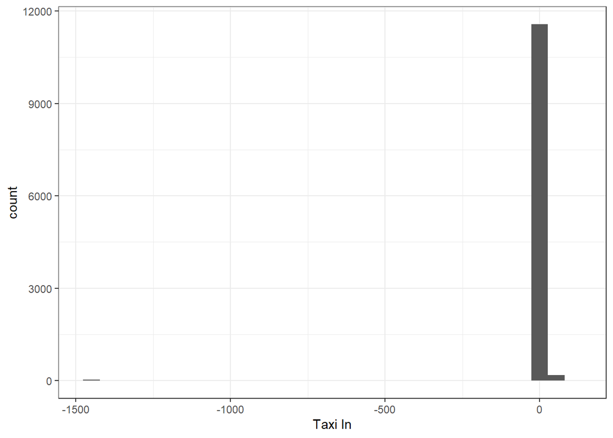

```r
ggplot(flights_2018, aes(x = Taxi_In)) +
  geom_histogram() +
  theme_bw() +
  xlab("Taxi In")
```

Grouped by Taxi_Out

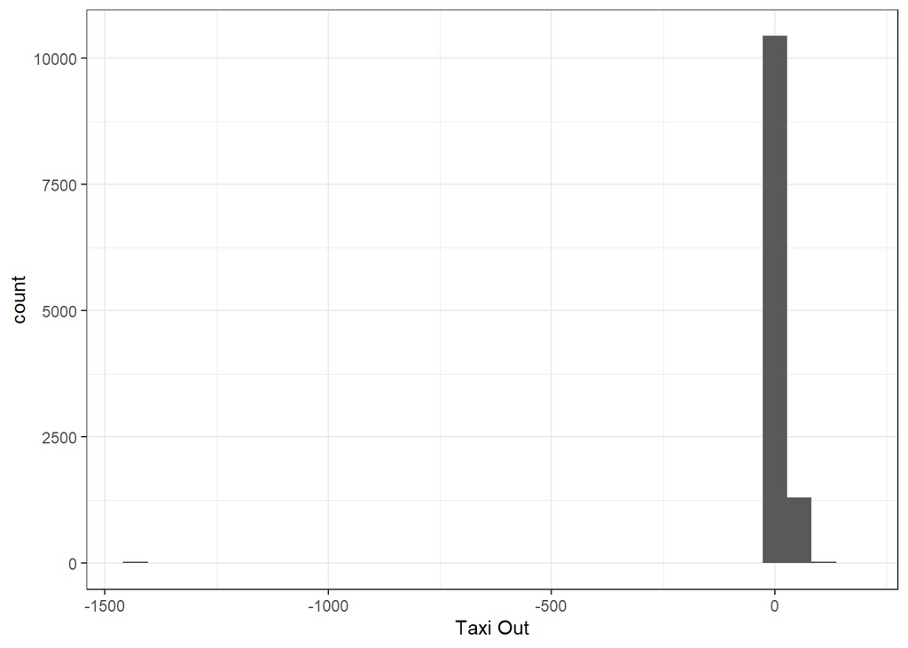

```r
ggplot(flights_2018, aes(x = Taxi_Out)) +
  geom_histogram() +
  theme_bw() +
  xlab("Taxi Out")
```

## Plots - Response vs Explanatory

Departure Delay vs Carrier Explanatory Variables

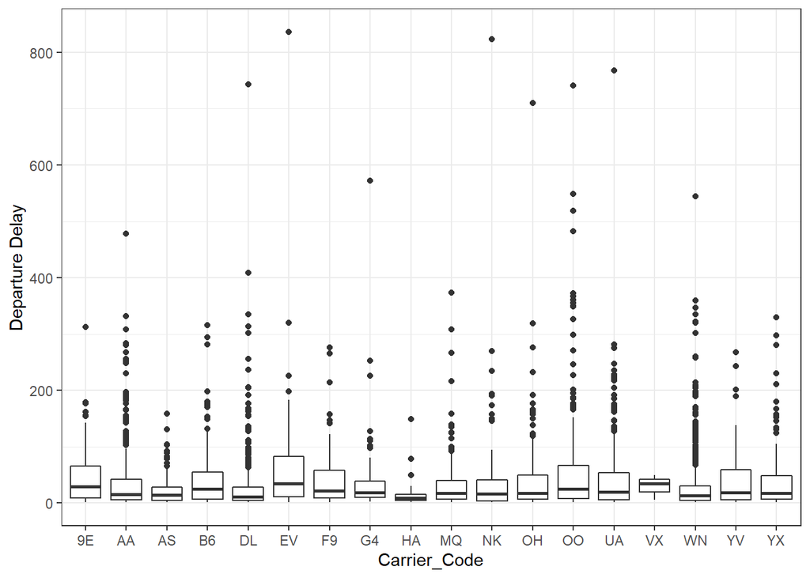

```r
# Carrier
flights_2018 %>%
  filter(Dep_Delay > 0) %>%
  ggplot(aes(x = Carrier_Code, y = Dep_Delay)) +
  geom_boxplot() +
  ylab("Departure Delay") +
  theme_bw()
```

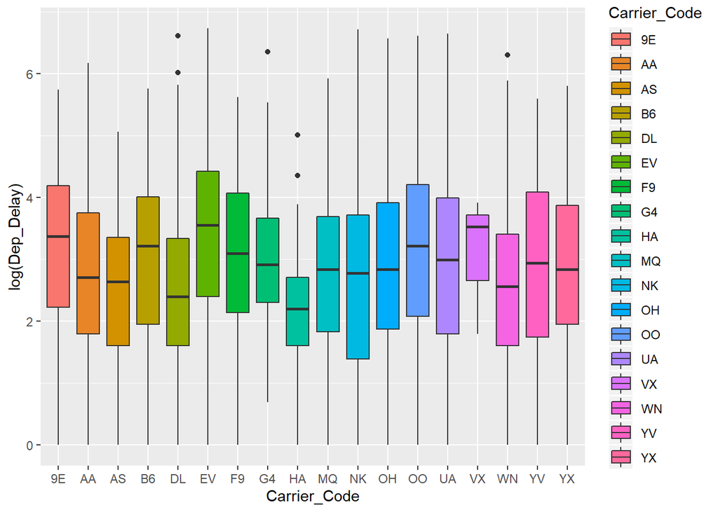

```r
ggplot(flights_2018, aes(x = Carrier_Code, y = log(Dep_Delay), fill = Carrier_Code)) +
  geom_boxplot(position = "dodge")
```

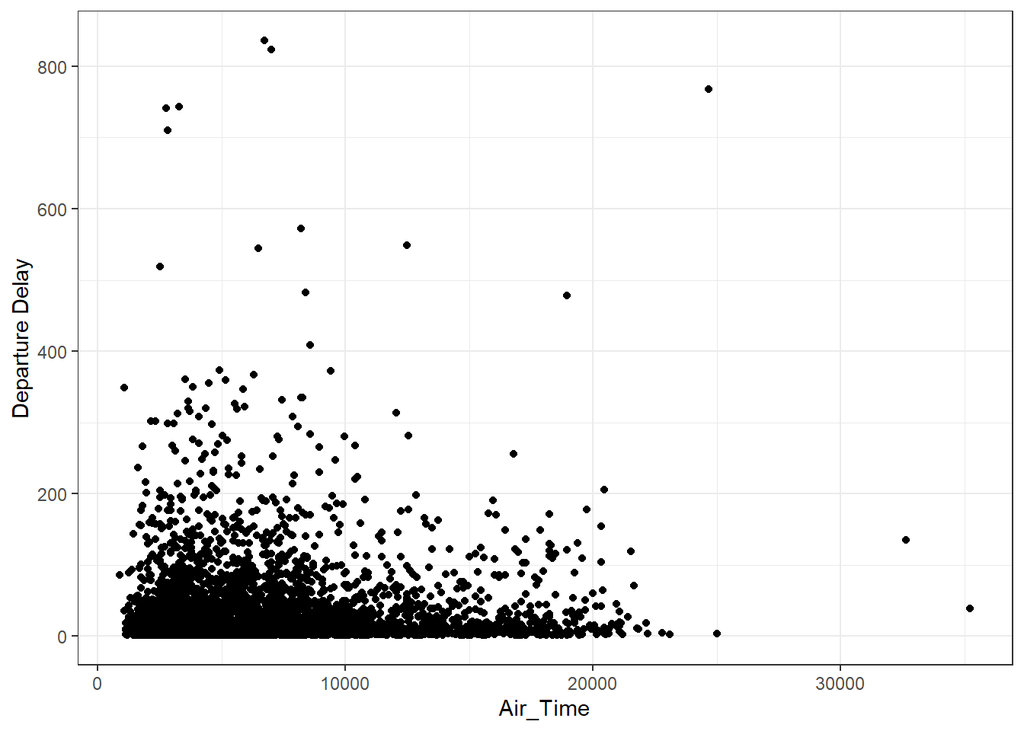

```r
# Air Time
flights_2018 %>%
  filter(Dep_Delay > 0) %>%
  ggplot(aes(x = Air_Time, y = Dep_Delay)) +
  geom_point() +
  ylab("Departure Delay") +
  theme_bw()
```

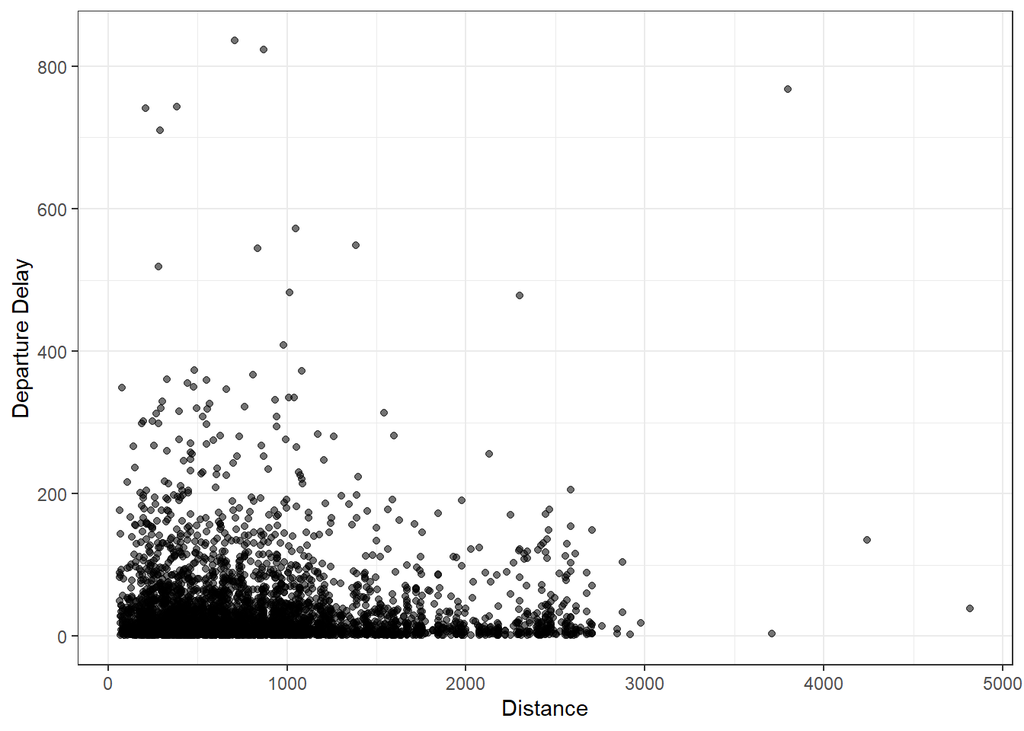

```r
# Distance
flights_2018 %>%
  filter(Dep_Delay > 0) %>%
  ggplot(aes(x = Distance, y = Dep_Delay, alpha = .1)) +
  geom_point() +
  ylab("Departure Delay") +
  theme_bw() +
  theme(legend.position = "none")
```

[figure not shown]

```r
# Origin
flights_2018 %>%
  filter(Dep_Delay > 0) %>%
  ggplot(aes(x = Origin, y = Dep_Delay, alpha = .1)) +
  geom_point() +
  ylab("Departure Delay") +
  theme_bw() +
  theme(legend.position = "none")
```

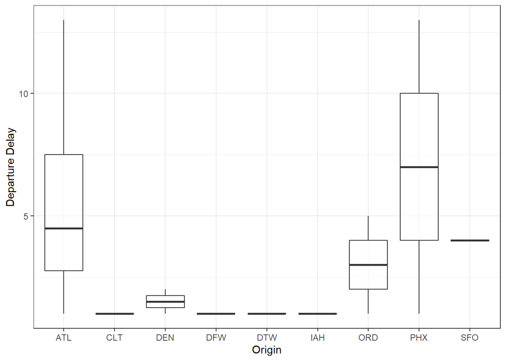

```r
# Origin - Filtered top 20 Origins
flights_2018 %>%
  group_by(Origin, Dep_Delay) %>%
  summarise(Num_Origin = n()) %>%
  arrange(desc(Num_Origin)) %>%
  filter(Dep_Delay > 0) %>%
  head(20) %>%
  ggplot(aes(x = Origin, y = Dep_Delay, alpha = .1)) +
  geom_boxplot() +
  ylab("Departure Delay") +
  theme_bw() +
  theme(legend.position = "none")
```

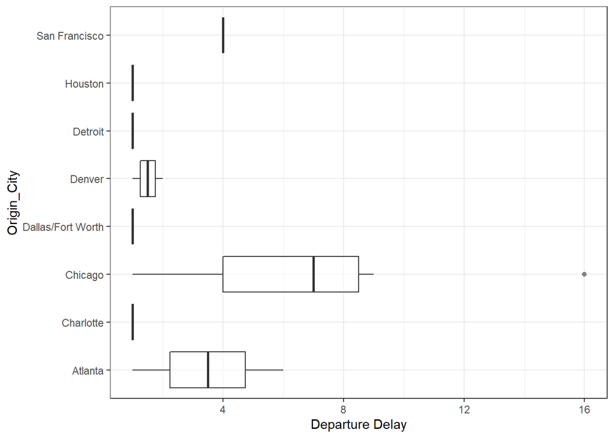

```r
# Origin Cities - Top
flights_2018 %>%
  group_by(Origin_City, Dep_Delay) %>%
  summarise(Num_Origin = n()) %>%
  arrange(desc(Num_Origin)) %>%
  filter(Dep_Delay > 0) %>%
  head(20) %>%
  ggplot(aes(x = Origin_City, y = Dep_Delay, alpha = .1)) +
  geom_boxplot() +
  ylab("Departure Delay") +
  theme_bw() +
  theme(legend.position = "none") +
  coord_flip()
```

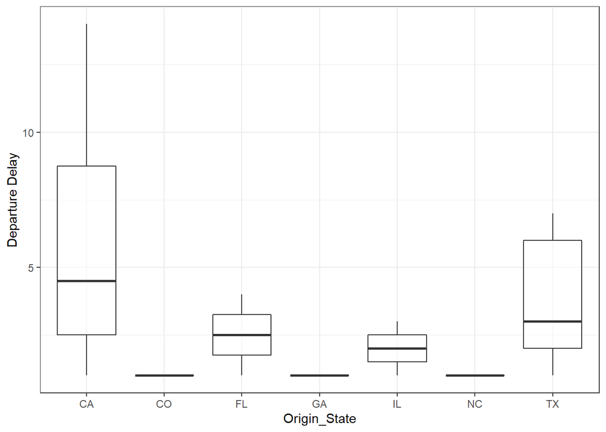

```r
# Origin States - Top
flights_2018 %>%
  group_by(Origin_State, Dep_Delay) %>%
  summarise(Num_Origin = n()) %>%
  arrange(desc(Num_Origin)) %>%
  filter(Dep_Delay > 0) %>%
  head(20) %>%
  ggplot(aes(x = Origin_State, y = Dep_Delay, alpha = .1)) +
  geom_boxplot() +
  ylab("Departure Delay") +
  theme_bw() +
  theme(legend.position = "none")
```

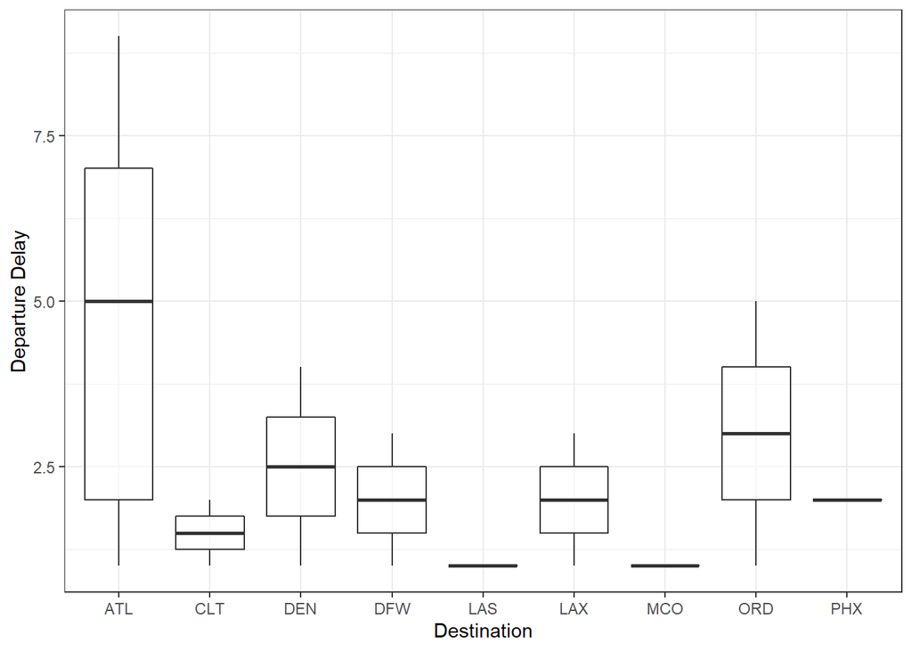

```r
# Destination - Filtered by top 20 desinations
flights_2018 %>%
  group_by(Dest, Dep_Delay) %>%
  summarise(Num_Dest = n()) %>%
  arrange(desc(Num_Dest)) %>%
  filter(Dep_Delay > 0) %>%
  head(20) %>%
  ggplot(aes(x = Dest, y = Dep_Delay, alpha = .1)) +
  geom_boxplot() +
  xlab("Destination") +
  ylab("Departure Delay") +
  theme_bw() +
  theme(legend.position = "none")
```

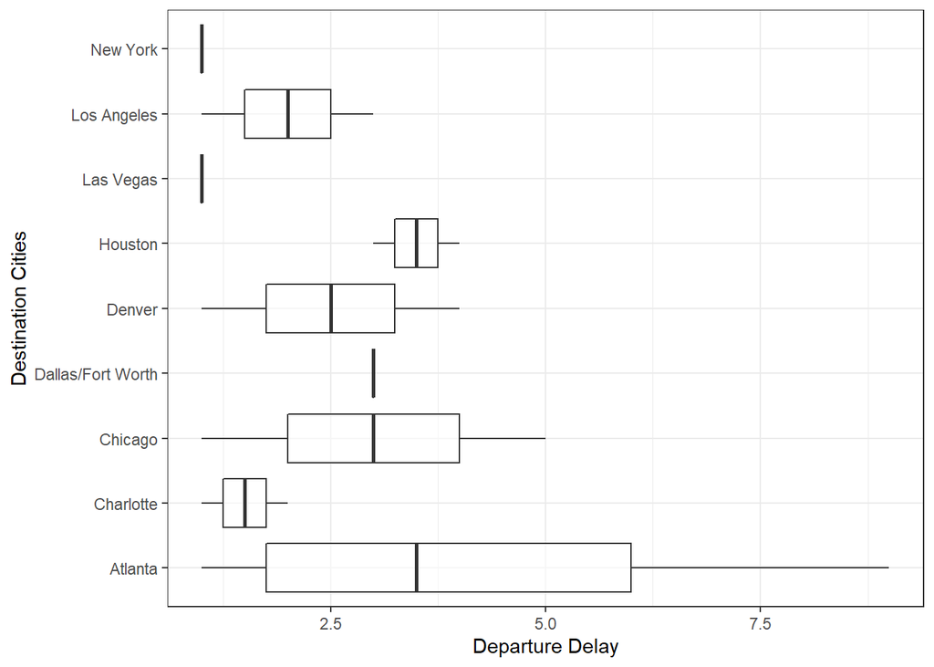

```r
# Destination Cities - Top
flights_2018 %>%
  group_by(Dest_City, Dep_Delay) %>%
  summarise(Num_Dest = n()) %>%
  arrange(desc(Num_Dest)) %>%
  filter(Dep_Delay > 0) %>%
  head(20) %>%
  ggplot(aes(x = Dest_City, y = Dep_Delay, alpha = .1)) +
  geom_boxplot() +
  xlab("Destination Cities") +
  ylab("Departure Delay") +
  theme_bw() +
  theme(legend.position = "none") +
  coord_flip()
```

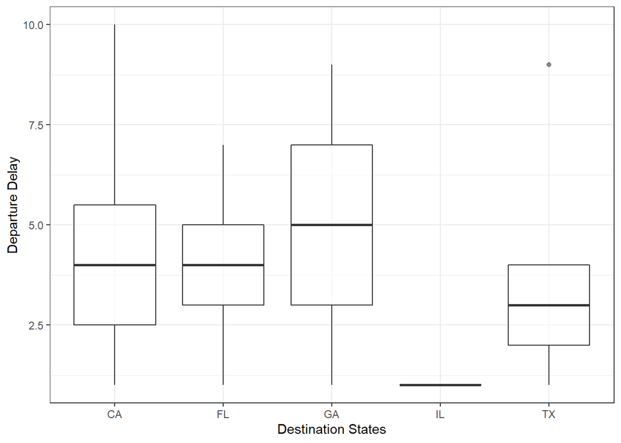

```r
# Destination States - Top
flights_2018 %>%
  group_by(Dest_State, Dep_Delay) %>%
  summarise(Num_Dest = n()) %>%
  arrange(desc(Num_Dest)) %>%
  filter(Dep_Delay > 0) %>%
  head(20) %>%
  ggplot(aes(x = Dest_State, y = Dep_Delay, alpha = .1)) +
  geom_boxplot() +
  xlab("Destination States") +
  ylab("Departure Delay") +
  theme_bw() +
  theme(legend.position = "none")
```

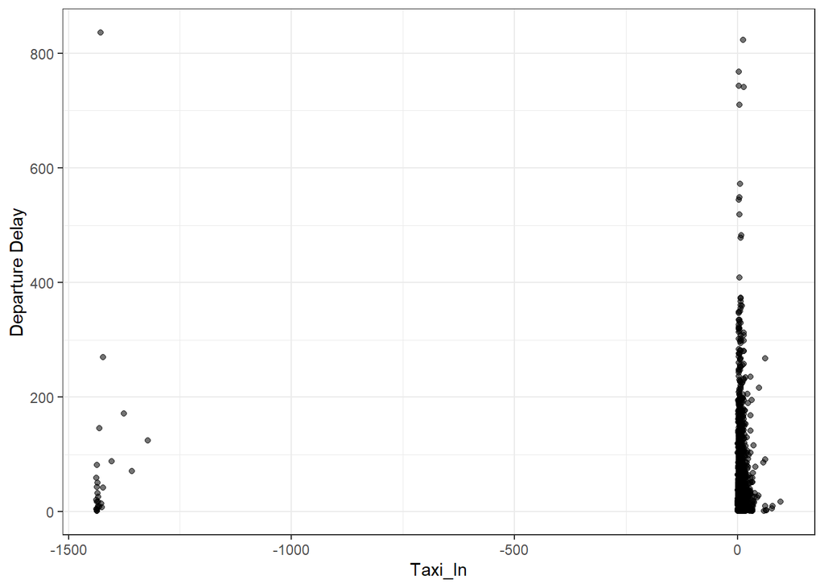

```r
# Taxi In
flights_2018 %>%
  filter(Dep_Delay > 0) %>%
  filter(!is.na(Taxi_In)) %>%
  ggplot(aes(x = Taxi_In, y = Dep_Delay, alpha = .1)) +
  geom_point() +
  ylab("Departure Delay") +
  theme_bw() +
  theme(legend.position = "none")
```

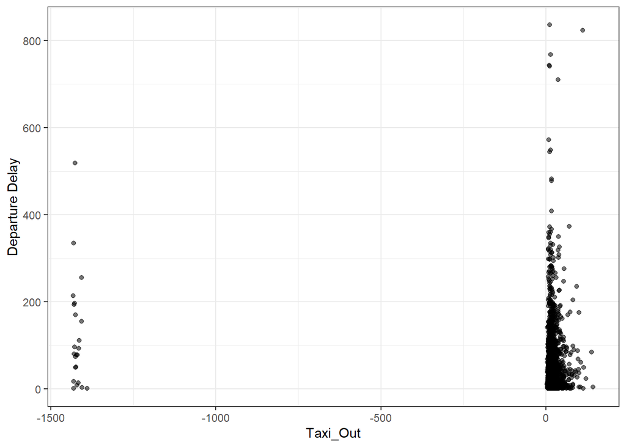

```r
# Taxi Out
flights_2018 %>%
  filter(Dep_Delay > 0) %>%
  filter(!is.na(Taxi_Out)) %>%
  ggplot(aes(x = Taxi_Out, y = Dep_Delay, alpha = .1)) +
  geom_point() +
  ylab("Departure Delay") +
  theme_bw() +
  theme(legend.position = "none")
```

Cancellation/Cancellation Codes vs Carrier Explanatory Variables

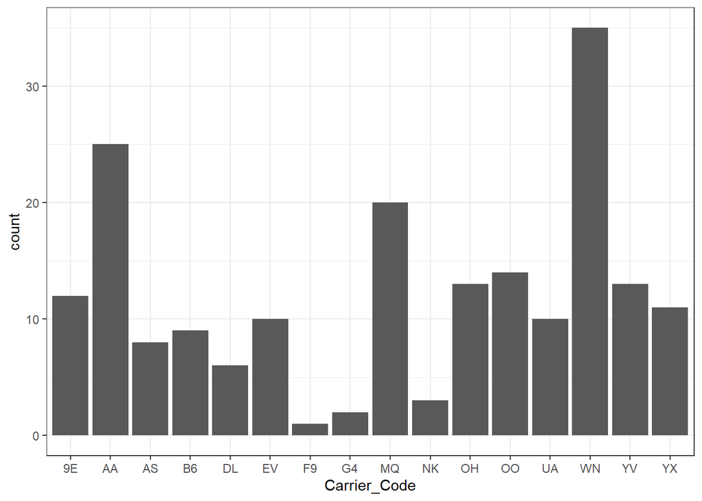

```r
# Carrier
flights_2018 %>%
  filter(Cancelled == "Yes") %>%
  ggplot(aes(x=Carrier_Code)) +
  geom_bar() +
  theme_bw()
```